# EMEA Content Market Analysis

**Data Portfolio - Project 2 | End-to-End Python Analysis** **Author:** Jashwanth Anand Shankar - MSc Business Analytics, Warwick Business School

## Business Question

> *Which production markets in EMEA showed the strongest output growth 2015-2023, and what does that imply for where production finance teams should concentrate location spend oversight?*

This notebook covers: data ingestion & cleaning, exploratory analysis, trend analysis, non-technical insight summary, and a clear recommendation.

## 1. Data Ingestion & Cleaning

```python
import pandas as pd
import numpy as np
import matplotlib.pyplot as plt
import matplotlib.ticker as mticker
import matplotlib.colors as mcolors
from scipy.stats import linregress
import warnings
warnings.filterwarnings("ignore")

plt.rcParams.update({
    "figure.facecolor": "white", "axes.facecolor": "white",
    "axes.grid": True, "grid.alpha": 0.25, "grid.linestyle": "--",
    "font.family": "sans-serif", "font.size": 10,
    "axes.spines.top": False, "axes.spines.right": False,
})
PALETTE = ["#1a1a2e","#16213e","#0f3460","#533483","#2d6a4f",
           "#1b4332","#6a3d9a","#b15928","#e31a1c","#ff7f00",
           "#33a02c","#1f78b4","#a6cee3","#fdbf6f","#cab2d6","#b2df8a"]

df_raw = pd.read_csv("emea_content_data.csv")
print(f"Raw dataset: {len(df_raw):,} rows x {df_raw.shape[1]} columns")
print(df_raw.dtypes)
df_raw.head()
```

```
Raw dataset: 4,167 rows x 9 columns
country_code        str
country_name        str
region              str
year              int64
genre               str
budget_m_gbp    float64
audience_m      float64
rating          float64
gdp_index       float64
dtype: object
```

|  | country_code | country_name | region | year | genre | budget_m_gbp | audience_m | rating | gdp_index |
| --- | --- | --- | --- | --- | --- | --- | --- | --- | --- |
| 0 | GB | United Kingdom | Northern Europe | 2015 | Romance | 10.31 | 1.38 | 8.0 | 1.0 |
| 1 | GB | United Kingdom | Northern Europe | 2015 | Drama | 4.72 | 6.56 | 7.2 | 1.0 |
| 2 | GB | United Kingdom | Northern Europe | 2015 | Crime | 0.72 | 2.34 | 7.2 | 1.0 |
| 3 | GB | United Kingdom | Northern Europe | 2015 | Action | 3.53 | 0.92 | 8.4 | 1.0 |
| 4 | GB | United Kingdom | Northern Europe | 2015 | Romance | 2.12 | 3.89 | 5.8 | 1.0 |

```python
print("DATA QUALITY AUDIT")
print("=" * 50)
print(f"Date range : {df_raw['year'].min()} - {df_raw['year'].max()}")
print(f"Markets    : {df_raw['country_name'].nunique()}")
print(f"Genres     : {df_raw['genre'].nunique()}")
miss = df_raw.isnull().sum()
miss_pct = (miss / len(df_raw) * 100).round(1)
audit_df = pd.DataFrame({"missing": miss, "pct_%": miss_pct})
print("\nMissing values:")
print(audit_df[audit_df["missing"] > 0].to_string())
print("\nDescriptive stats:")
print(df_raw[["budget_m_gbp","audience_m","rating"]].describe().round(2).to_string())
```

```
DATA QUALITY AUDIT
==================================================
Date range : 2015 - 2023
Markets    : 16
Genres     : 8

Missing values:
              missing  pct_%
budget_m_gbp      167    4.0

Descriptive stats:
       budget_m_gbp  audience_m   rating
count       4000.00     4167.00  4167.00
mean           3.33        3.95     7.21
std            2.32        4.14     1.18
min            0.30        0.16     3.20
25%            1.76        1.54     6.40
50%            2.77        2.68     7.20
75%            4.25        4.81     8.00
max           28.69       50.11     9.80
```

```python
df = df_raw.copy()
# Impute missing budget with country-year median, fallback to country median
df["budget_m_gbp"] = df.groupby(["country_code","year"])["budget_m_gbp"]                        .transform(lambda x: x.fillna(x.median()))
df["budget_m_gbp"] = df.groupby("country_code")["budget_m_gbp"]                        .transform(lambda x: x.fillna(x.median()))
df = df[(df["rating"] >= 1) & (df["rating"] <= 10)]
print(f"Clean dataset: {len(df):,} rows | Remaining NAs: {df.isnull().sum().sum()}")
print("Imputation: country-year median preserves market-specific cost structures.")
```

```
Clean dataset: 4,167 rows | Remaining NAs: 0
Imputation: country-year median preserves market-specific cost structures.
```

## 2. Exploratory Analysis - Market Overview

```python
annual = df.groupby(["country_name","year"]).agg(
    productions=("budget_m_gbp","count"),
    total_spend_m=("budget_m_gbp","sum"),
    avg_rating=("rating","mean"),
    total_audience_m=("audience_m","sum"),
).reset_index().round(2)

market_totals = annual.groupby("country_name").agg(
    total_productions=("productions","sum"),
    total_spend_m=("total_spend_m","sum"),
    avg_rating=("avg_rating","mean"),
).sort_values("total_spend_m", ascending=False).round(2)
print("Market overview (2015-2023):")
print(market_totals.to_string())
```

```
Market overview (2015-2023):
                total_productions  total_spend_m  avg_rating
country_name
Norway                        315        1230.67        7.15
United Kingdom                287        1169.69        7.37
Netherlands                   277        1056.70        7.10
France                        282        1047.89        7.25
Germany                       262         993.13        7.26
Ireland                       276         987.20        7.29
Sweden                        294         952.36        7.26
Austria                       269         946.51        7.25
Denmark                       249         946.14        7.32
Spain                         266         854.15        7.07
Belgium                       261         851.11        7.27
Italy                         258         813.87        7.20
Portugal                      241         609.67        7.10
Poland                        217         569.85        7.04
South Africa                  228         490.40        7.17
Nigeria                       185         280.20        7.08
```

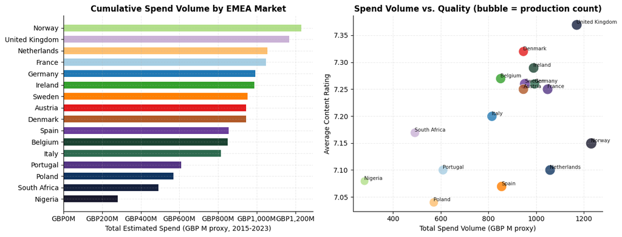

```
Chart saved.
```

```python
fig, axes = plt.subplots(1, 2, figsize=(13, 5))
ms = market_totals.sort_values("total_spend_m")
colors_bar = PALETTE[:len(ms)]
axes[0].barh(ms.index, ms["total_spend_m"], color=colors_bar, height=0.6)
axes[0].set_xlabel("Total Estimated Spend (GBP M proxy, 2015-2023)")
axes[0].set_title("Cumulative Spend Volume by EMEA Market", fontweight="bold")
axes[0].xaxis.set_major_formatter(mticker.FuncFormatter(lambda x,_: f"GBP{x:,.0f}M"))
for i, (mkt, row) in enumerate(market_totals.iterrows()):
    axes[1].scatter(row["total_spend_m"], row["avg_rating"],
                    s=row["total_productions"]*0.8, alpha=0.8,
                    color=PALETTE[i], edgecolors="white", linewidths=0.6)
    axes[1].annotate(mkt, (row["total_spend_m"], row["avg_rating"]),
                     fontsize=7.5, ha="left", va="bottom", alpha=0.9)
axes[1].set_xlabel("Total Spend Volume (GBP M proxy)")
axes[1].set_ylabel("Average Content Rating")
axes[1].set_title("Spend Volume vs. Quality (bubble = production count)", fontweight="bold")
plt.tight_layout()
plt.savefig("p2_market_overview.png", dpi=150, bbox_inches="tight")
plt.show()
print("Chart saved.")
```

## 3. Trend Analysis - CAGR & Year-on-Year Growth by Market

```python
def calc_cagr(start, end, n):
    if not start or not end or start <= 0:
        return np.nan
    return round(((end / start) ** (1 / n) - 1) * 100, 1)

annual_sorted = annual.sort_values(["country_name","year"])
annual_sorted["yoy_pct"] = annual_sorted.groupby("country_name")["productions"].pct_change() * 100

cagr_rows = []
for mkt, g in annual_sorted.groupby("country_name"):
    p2015 = g[g["year"]==2015]["productions"].values
    p2023 = g[g["year"]==2023]["productions"].values
    if len(p2015) and len(p2023):
        cagr_rows.append({"country_name": mkt,
                           "prod_2015": p2015[0],
                           "prod_2023": p2023[0],
                           "cagr_pct": calc_cagr(p2015[0], p2023[0], 8)})
cagr_df = pd.DataFrame(cagr_rows).sort_values("cagr_pct", ascending=False)
print("CAGR by market (production output 2015->2023):")
print(cagr_df.to_string(index=False))
```

```
CAGR by market (production output 2015->2023):
  country_name  prod_2015  prod_2023  cagr_pct
       Belgium          3         39      37.8
       Germany         11         40      17.5
   Netherlands         19         47      12.0
        Norway         20         47      11.3
United Kingdom         18         39      10.1
        Sweden         21         45      10.0
       Austria         22         38       7.1
         Italy         21         33       5.8
        France         32         46       4.6
         Spain         29         41       4.4
        Poland         19         26       4.0
       Denmark         31         32       0.4
      Portugal         27         25      -1.0
  South Africa         21         18      -1.9
       Ireland         35         25      -4.1
       Nigeria         23         16      -4.4
```

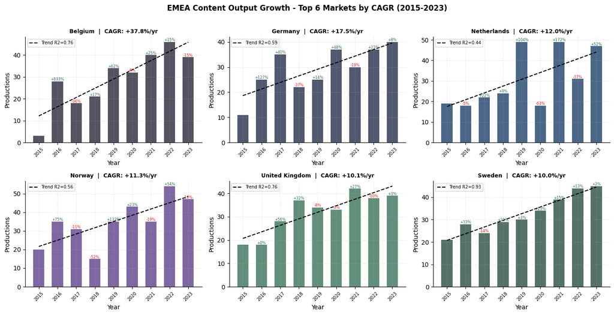

```
Chart saved.
```

```python
top6 = cagr_df.head(6)["country_name"].tolist()
fig, axes = plt.subplots(2, 3, figsize=(14, 7))
axes = axes.flatten()
for i, (market, ax) in enumerate(zip(top6, axes)):
    sub = annual_sorted[annual_sorted["country_name"] == market].copy()
    ax.bar(sub["year"], sub["productions"], color=PALETTE[i], alpha=0.75, width=0.6)
    slope, intercept, r, *_ = linregress(sub["year"], sub["productions"])
    x_fit = np.array(sub["year"])
    ax.plot(x_fit, slope*x_fit + intercept, color="black", lw=1.5,
            linestyle="--", label=f"Trend R2={r**2:.2f}")
    cagr_val = cagr_df[cagr_df["country_name"]==market]["cagr_pct"].values[0]
    ax.set_title(f"{market}  |  CAGR: {cagr_val:+.1f}%/yr", fontweight="bold", fontsize=9)
    ax.set_xlabel("Year"); ax.set_ylabel("Productions")
    ax.set_xticks(sub["year"]); ax.tick_params(axis="x", rotation=45, labelsize=7)
    ax.legend(fontsize=7)
    for _, row in sub.iterrows():
        if pd.notna(row["yoy_pct"]):
            c = "#2d6a4f" if row["yoy_pct"] >= 0 else "#e31a1c"
            ax.text(row["year"], row["productions"]+0.3,
                    f"{row['yoy_pct']:+.0f}%", ha="center", fontsize=6, color=c)
plt.suptitle("EMEA Content Output Growth - Top 6 Markets by CAGR (2015-2023)",
             fontweight="bold", fontsize=12, y=1.01)
plt.tight_layout()
plt.savefig("p2_trend_top6.png", dpi=150, bbox_inches="tight")
plt.show()
print("Chart saved.")
```

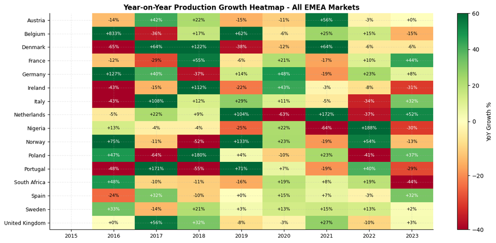

```
Chart saved.
```

```python
pivot_yoy = annual_sorted.pivot(index="country_name", columns="year", values="yoy_pct")
fig, ax = plt.subplots(figsize=(13, 6))
cmap = plt.cm.RdYlGn
norm = mcolors.TwoSlopeNorm(vmin=-40, vcenter=0, vmax=60)
im = ax.imshow(pivot_yoy.values, cmap=cmap, norm=norm, aspect="auto")
ax.set_xticks(range(len(pivot_yoy.columns))); ax.set_xticklabels(pivot_yoy.columns, fontsize=9)
ax.set_yticks(range(len(pivot_yoy.index))); ax.set_yticklabels(pivot_yoy.index, fontsize=9)
for i in range(len(pivot_yoy.index)):
    for j in range(len(pivot_yoy.columns)):
        val = pivot_yoy.values[i, j]
        if not np.isnan(val):
            ax.text(j, i, f"{val:+.0f}%", ha="center", va="center",
                    fontsize=7.5, color="black" if abs(val)<30 else "white")
plt.colorbar(im, ax=ax, label="YoY Growth %")
ax.set_title("Year-on-Year Production Growth Heatmap - All EMEA Markets", fontweight="bold", fontsize=12)
plt.tight_layout()
plt.savefig("p2_yoy_heatmap.png", dpi=150, bbox_inches="tight")
plt.show()
print("Chart saved.")
```

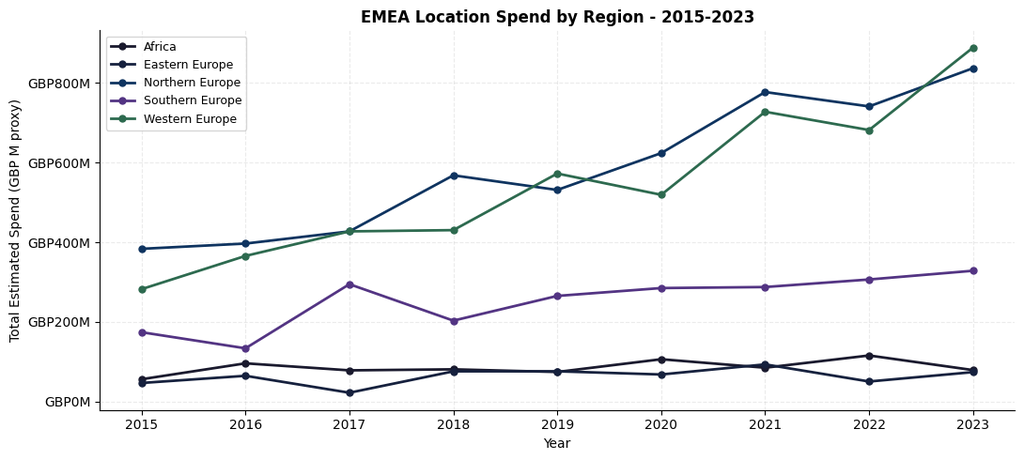

```
Chart saved.
```

```python
region_annual = df.groupby(["region","year"])["budget_m_gbp"].sum().reset_index()
region_annual.columns = ["region","year","spend_m"]
fig, ax = plt.subplots(figsize=(11, 5))
for i, region in enumerate(region_annual["region"].unique()):
    sub = region_annual[region_annual["region"]==region].sort_values("year")
    ax.plot(sub["year"], sub["spend_m"], marker="o", color=PALETTE[i],
            linewidth=2, label=region, markersize=5)
ax.set_xlabel("Year")
ax.set_ylabel("Total Estimated Spend (GBP M proxy)")
ax.set_title("EMEA Location Spend by Region - 2015-2023", fontweight="bold")
ax.yaxis.set_major_formatter(mticker.FuncFormatter(lambda x,_: f"GBP{x:.0f}M"))
ax.legend(fontsize=9)
plt.tight_layout()
plt.savefig("p2_spend_by_region.png", dpi=150, bbox_inches="tight")
plt.show()
print("Chart saved.")
```